# Integrated Final Project

Jordan Wheeler

### *Introduction*

Deciding which career path to follow is a big deal. It will determine how you will spend every day of your life. It will affect your family and your lifestyle. Many people are advised to follow a career path that they are interested in; something that they will enjoy doing for the rest of their life. Even though one could argue that this should be the driving factor for the career one chooses, it is often not. People will often decide career paths based off of other factors: easiness, money, prestige, etc.

### *Data*

The data that I am using for this project is the Prestige dataset from the ‘car’ package in R. This data set consists of 102 observations (rows), which are keyed by different job types. The dataset also includes 6 variables (columns), which consist of different attributes of each job type listed.

The Variables:

| Columns | Measurement | Description |
| --- | --- | --- |
| Education | Years | Average education of occupation |
| Income | Dollars | Average income of incumbents |
| Women | Percent | Percentage of incumbents who are women |
| Prestige | Prestige Score | Pineo-Porter prestige score for occupation |
| Census | Code | Canadian Census occupational code |
| Type | Professional, Blue Collar, White Collar | Type of occupation |

Dataset Sample:

|  | education | income | women | prestige | census | type |
| --- | --- | --- | --- | --- | --- | --- |
| gov.administrators | 13.11 | 12351 | 11.16 | 68.8 | 1113 | prof |
| general.managers | 12.26 | 25879 | 4.02 | 69.1 | 1130 | prof |
| accountants | 12.77 | 9271 | 15.70 | 63.4 | 1171 | prof |
| purchasing.officers | 11.42 | 8865 | 9.11 | 56.8 | 1175 | prof |
| chemists | 14.62 | 8403 | 11.68 | 73.5 | 2111 | prof |
| physicists | 15.64 | 11030 | 5.13 | 77.6 | 2113 | prof |

### *Research Questions*

The question I am trying to answer is whether or not I can model the prestige of each job based on the different factors given for each entry. The second question I am going to answer is whether or not there is a difference between prestige of professional, white collar, and blue collar jobs.

### *Topic One: Multiple Regression*

In this section we will create a linear regression model based of all the quantitative variables, removing the variables that are highly correlated. To do this, we will first look at the correlation of all the variables.

Variable Correlations:

|  | education | income | women | prestige | census |
| --- | --- | --- | --- | --- | --- |
| education | 1.0000000 | 0.5775802 | 0.0618529 | 0.8501769 | -0.8230882 |
| income | 0.5775802 | 1.0000000 | -0.4410593 | 0.7149057 | -0.3610023 |
| women | 0.0618529 | -0.4410593 | 1.0000000 | -0.1183342 | -0.2270028 |
| prestige | 0.8501769 | 0.7149057 | -0.1183342 | 1.0000000 | -0.6345103 |
| census | -0.8230882 | -0.3610023 | -0.2270028 | -0.6345103 | 1.0000000 |

When I look at the correlation table I look to see if any of the independent variables are highly correlated, meaning the absolute value of their correlation is greater than .7. As it turns out, the variables Census and Education are highly correlated. We do not want to remove both of the variables, just one. To determine which variable we need to remove we need to look at each of the two variables’ correlation with the dependent variable. In other words, what is the correlation between Census and Prestige, and what is the correlation between Education and Prestige. Since Census and Prestige correlation is less than the Education and Prestige correlation, we will remove the Census variable.

Variable Correlations without ‘Census’:

|  | education | income | women | prestige |
| --- | --- | --- | --- | --- |
| education | 1.0000000 | 0.5775802 | 0.0618529 | 0.8501769 |
| income | 0.5775802 | 1.0000000 | -0.4410593 | 0.7149057 |
| women | 0.0618529 | -0.4410593 | 1.0000000 | -0.1183342 |
| prestige | 0.8501769 | 0.7149057 | -0.1183342 | 1.0000000 |

After removing the Census variable, there are no more independent variables that are highly correlated with eachother. Now that we have taken care of the correlated variables, we will build our regression model on the remaining variables.

Model Coefficient Table:

|  | Estimate | Std. Error | t value | Pr(>\|t\|) |
| --- | --- | --- | --- | --- |
| (Intercept) | -6.7943342 | 3.2390886 | -2.0976067 | 0.0385131 |
| education | 4.1866373 | 0.3887013 | 10.7708353 | 0.0000000 |
| income | 0.0013136 | 0.0002778 | 4.7287593 | 0.0000076 |
| women | -0.0089052 | 0.0304071 | -0.2928648 | 0.7702447 |

From this table, we can see that there is one variable that does not have a significant p-value: Women. We will deal with this insignificant variable later on in the “Model Building” section. The next step we need to do is check our assumptions for linear regression: Normality, Constant Variance and Linearity.

##### *Check for Normality*

For this assumption I will check and see if the model’s residuals (error terms) are normally distributed.

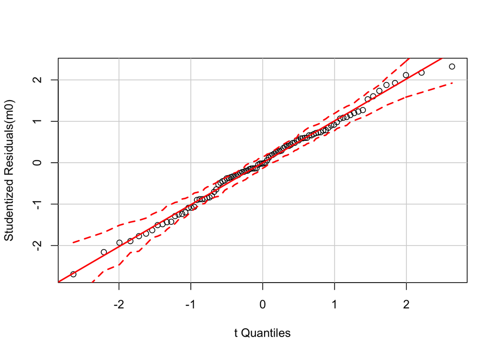

As we can see, the values fall within the dashed red lines, meaning that the model’s residuals are normally distributed. To see this even more, we will look at the density curve of the data.

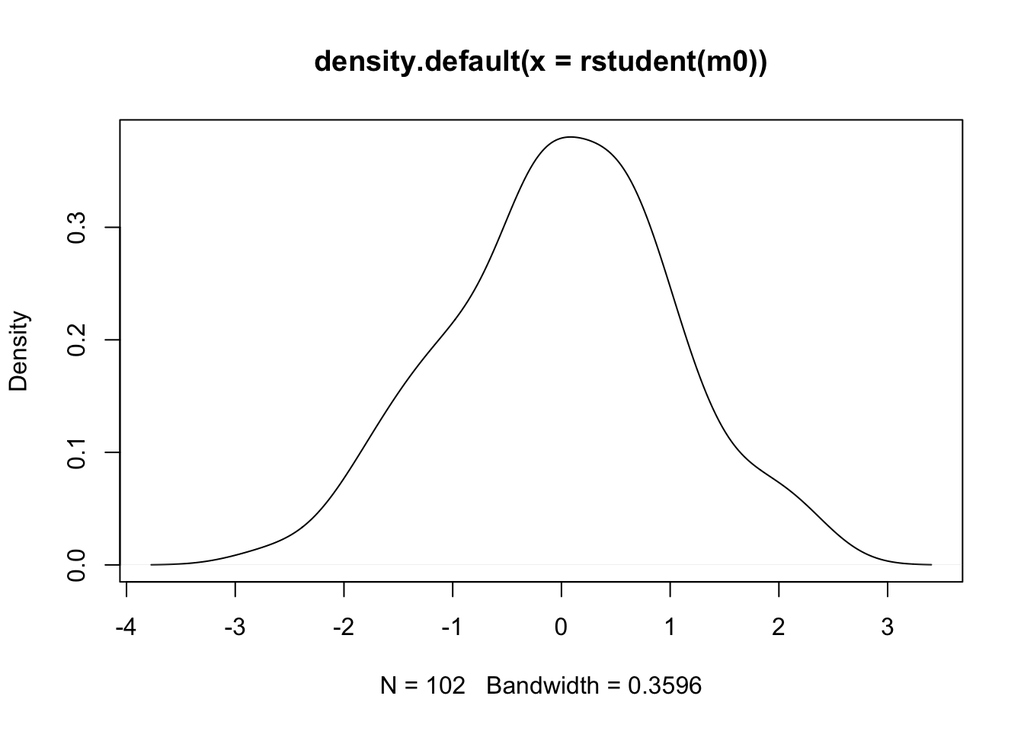

Furthermore, we can see that the density curve of the model’s residuals follow the shape of a “bell curve”, meaning that the residuals are normally distributed.

##### *Check for Constant Variance*

For this assumption, I will check and see if there is constant variance in the residuals.

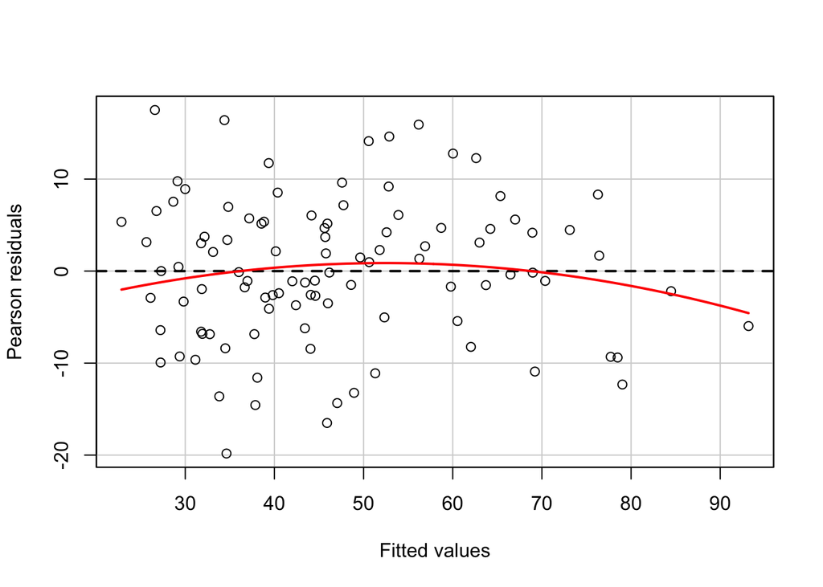

As we can see, the residuals don’t seem to quite have constant variance. As the values in Prestige get larger, the variance of the residuals seem to get smaller. This creates a “funnel” shape. This means that we will need to transform the dependent variable, Prestige. Since there is a “funnel” shape in the residuals, this indicates that we need to transform the dependent variable with by taking it to the power of a number less than 1 (some sort of root transformation).

##### *Check for Linearity*

For this assumption, I will check to make sure each of the independent variables are linearally related to the dependent variable.

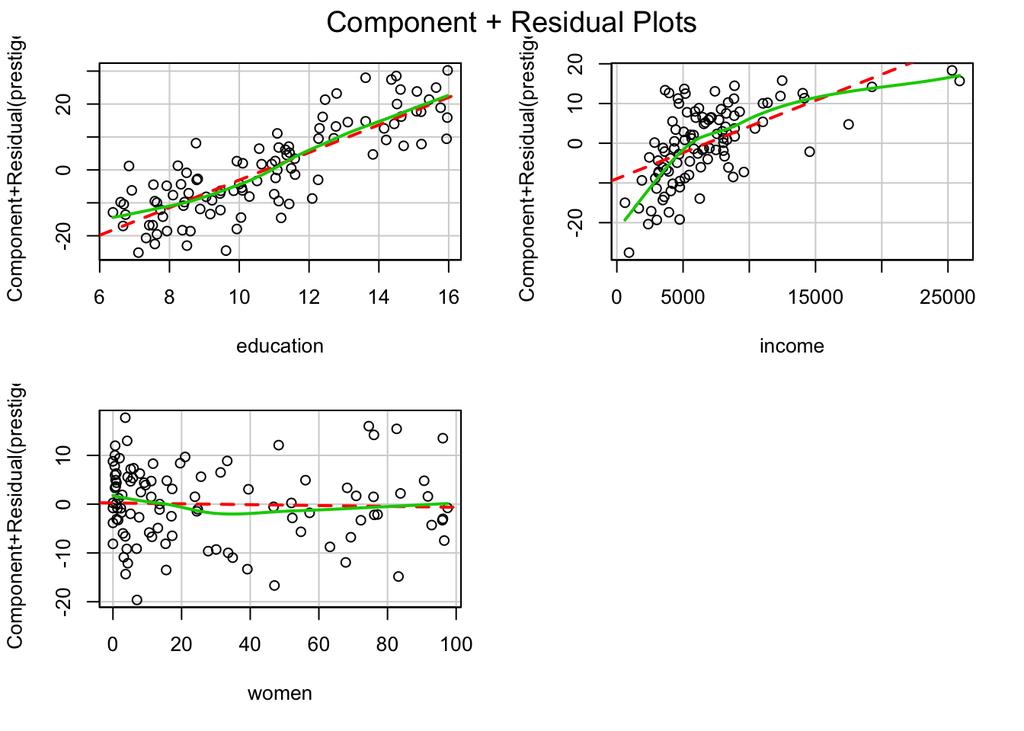

##### *Transformed Model*

New Transformed Model Variables:

|  | Estimate | Std. Error | t value | Pr(>\|t\|) |
| --- | --- | --- | --- | --- |
| (Intercept) | 13.6028924 | 8.1596001 | 1.667103 | 0.0987875 |
| income | 0.0015952 | 0.0002444 | 6.526984 | 0.0000000 |
| I(income^1.4) | -0.0000225 | 0.0000039 | -5.805909 | 0.0000001 |
| education | 1.7424176 | 0.7747735 | 2.248938 | 0.0268267 |
| sqrt(education) | -7.8623550 | 5.0333162 | -1.562063 | 0.1215985 |
| women | -0.0781280 | 0.0401025 | -1.948205 | 0.0543417 |
| I(women^1.3) | 0.0243367 | 0.0102369 | 2.377350 | 0.0194413 |

After messing around with different transformations of the dependent and independent variables, I came up with this model. We will now go back and recheck all of our assumptions.

##### *Check for Normality*

For this assumption I will check and see if the model’s residuals (error terms) are normally distributed.

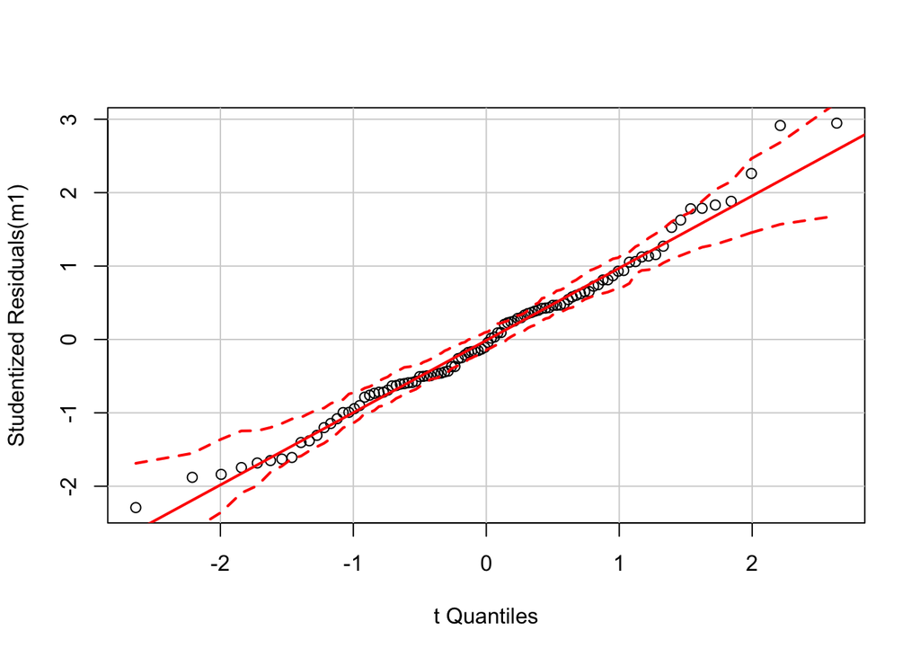

As we can see, the new transformed model’s residuals are still normally distributed.

##### *Check for Constant Variance*

For this assumption, I will check and see if there is constant variance in the residuals.

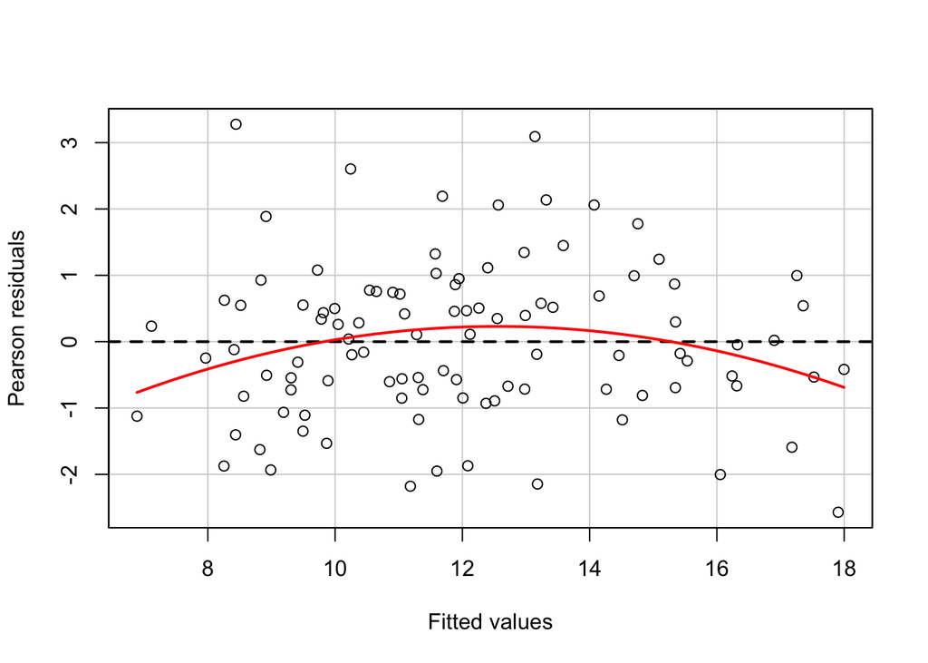

As we can see, the transformation of the dependent variable (Prestige^.65) seemed to correct this assumption about constant variance in the residuals.

##### *Check for Linearity*

For this assumption, I will check to make sure each of the independent variables are linearally related to the dependent variable.

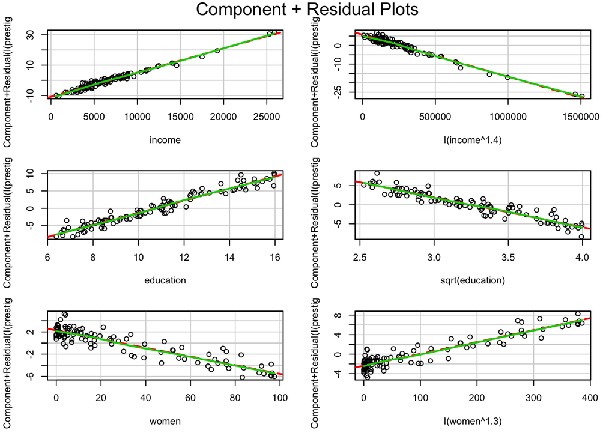

As we can see, the added independent variables and the transformed independent variables corrected the issue of linearity.

### *Topic Two: Model Building*

In this section, we will take the previous model that we created in Topic One, and build the “best” model. We will use the Adjusted R Squared value to evaluate each model and choose the “best” model. There are three different methods we will use for model building: Forward Selection, Backward Elimination, and Stepwise Selection.

##### *Forward Selection*

In Forward Selection we will start with an empty model and slowly add in one variable at a time. The variable that gets added is the one with the lowest p-value, meaning the most significant variable.

Forward Selection:

|  | income | I(income^1.4) | education | sqrt(education) | women | I(women^1.3) |
| --- | --- | --- | --- | --- | --- | --- |
| 1 ( 1 ) |  |  | * |  |  |  |
| 2 ( 1 ) | * |  | * |  |  |  |
| 3 ( 1 ) | * | * | * |  |  |  |
| 4 ( 1 ) | * | * | * |  |  | * |
| 5 ( 1 ) | * | * | * |  | * | * |

This table shows you which variables to include when for the number of variables you want to include. To know how many variables to include, we need to look at the Adjusted R Square value for each:

0.6978407, 0.7688099, 0.8087149, 0.8242529, 0.8276589

Looking at these adjusted R squared values, we can see that 4 or 5 variables give the highest adjusted R squared. Since they are within .01 of eachother, we will use the model with 4 variables since the fewer the variables, the better. We then can refer back to the table with the “*" and see that for 4 variables, we need to include the following variables:

‘income’, ‘I(income^1.4)’, ‘education’, and ‘I(women^1.3)’

##### *Backward Elimination*

In Backward Elimination we will start with a full model and slowly remove one variable at a time. The variable that gets removed is the one with the biggest p-value, meaning the least significant variable.

Backward Elimination:

|  | income | I(income^1.4) | education | sqrt(education) | women | I(women^1.3) |
| --- | --- | --- | --- | --- | --- | --- |
| 1 ( 1 ) |  |  | * |  |  |  |
| 2 ( 1 ) | * |  | * |  |  |  |
| 3 ( 1 ) | * | * | * |  |  |  |
| 4 ( 1 ) | * | * | * |  |  | * |
| 5 ( 1 ) | * | * | * |  | * | * |

This table shows you which variables to include based on the number of variables you want to include. To know how many variables to include, we need to look at the Adjusted R Square value for each:

0.6978407, 0.7688099, 0.8087149, 0.8242529, 0.8276589

Looking at these adjusted R squared values, we can see that 4 or 5 variables give the highest adjusted R squared. Since they are within .01 of eachother, we will use the model with 4 variables since the fewer the variables, the better. We then can refer back to the table with the “*" and see that for 4 variables, we need to include the following variables:

‘income’, ‘I(income^1.4)’, ‘education’, and ‘I(women^1.3)’

##### *Stepwise Selection*

|  | income | I(income^1.4) | education | sqrt(education) | women | I(women^1.3) |
| --- | --- | --- | --- | --- | --- | --- |
| 1 ( 1 ) |  |  | * |  |  |  |
| 2 ( 1 ) | * |  | * |  |  |  |
| 3 ( 1 ) | * | * | * |  |  |  |
| 4 ( 1 ) | * | * | * |  |  | * |
| 5 ( 1 ) | * | * | * |  | * | * |

This table shows you which variables to include based on the number of variables you want to include. To know how many variables to include, we need to look at the Adjusted R Square value for each:

0.6978407, 0.7688099, 0.8087149, 0.8242529, 0.8276589

Looking at these adjusted R squared values, we can see that 4 or 5 variables give the highest adjusted R squared. Since they are within .01 of eachother, we will use the model with 4 variables since the fewer the variables, the better. We then can refer back to the table with the “*" and see that for 4 variables, we need to include the following variables:

‘income’, ‘I(income^1.4)’, ‘education’, and ‘I(women^1.3)’

Since we got the same model for all three methods, we will use the model with 4 variables.

The Best Selected Model’s Coefficients and P-Value:

|  | Estimate | Std. Error | t value | Pr(>\|t\|) |
| --- | --- | --- | --- | --- |
| (Intercept) | 0.7017170 | 0.6451463 | 1.087687 | 0.2794288 |
| income | 0.0016331 | 0.0002477 | 6.594243 | 0.0000000 |
| I(income^1.4) | -0.0000226 | 0.0000039 | -5.764683 | 0.0000001 |
| education | 0.5125332 | 0.0678027 | 7.559184 | 0.0000000 |
| I(women^1.3) | 0.0044793 | 0.0014409 | 3.108748 | 0.0024660 |

### *Topic Three: t-Tests*

For the section, we will break the Prestige dataset into 3 different groups, the Blue Collar jobs, the White Collar jobs, and the Professional Jobs.

Blue Collar Dataset Sample:

|  | education | income | women | prestige | census | type |
| --- | --- | --- | --- | --- | --- | --- |
| nursing.aides | 9.45 | 3485 | 76.14 | 34.9 | 3135 | bc |
| NA | NA | NA | NA | NA | NA | NA |
| NA.1 | NA | NA | NA | NA | NA | NA |
| service.station.attendant | 9.93 | 2370 | 3.69 | 23.3 | 5145 | bc |
| firefighters | 9.47 | 8895 | 0.00 | 43.5 | 6111 | bc |
| policemen | 10.93 | 8891 | 1.65 | 51.6 | 6112 | bc |

White Collar Dataset Sample:

|  | education | income | women | prestige | census | type |
| --- | --- | --- | --- | --- | --- | --- |
| medical.technicians | 12.79 | 5180 | 76.04 | 67.5 | 3156 | wc |
| radio.tv.announcers | 12.71 | 7562 | 11.15 | 57.6 | 3337 | wc |
| secretaries | 11.59 | 4036 | 97.51 | 46.0 | 4111 | wc |
| typists | 11.49 | 3148 | 95.97 | 41.9 | 4113 | wc |
| bookkeepers | 11.32 | 4348 | 68.24 | 49.4 | 4131 | wc |
| tellers.cashiers | 10.64 | 2448 | 91.76 | 42.3 | 4133 | wc |

Professional Dataset Sample:

|  | education | income | women | prestige | census | type |
| --- | --- | --- | --- | --- | --- | --- |
| gov.administrators | 13.11 | 12351 | 11.16 | 68.8 | 1113 | prof |
| general.managers | 12.26 | 25879 | 4.02 | 69.1 | 1130 | prof |
| accountants | 12.77 | 9271 | 15.70 | 63.4 | 1171 | prof |
| purchasing.officers | 11.42 | 8865 | 9.11 | 56.8 | 1175 | prof |
| chemists | 14.62 | 8403 | 11.68 | 73.5 | 2111 | prof |
| physicists | 15.64 | 11030 | 5.13 | 77.6 | 2113 | prof |

Now I will perform a t-test to see if there is a signficant difference between the Prestige of each type of job.

##### *Professional vs Blue Collar*

Here I will look at the Prestige of Professional and Blue Collar jobs and see if there is a significant difference between them.

The Null Hypothesis is that there is no difference between them and the Alternative Hypothesis is that there is a difference between them.

##### *Professional vs White Collar*

Here I will look at the Prestige of Professional and White Collar jobs and see if there is a significant difference between them.

The Null Hypothesis is that there is no difference between them and the Alternative Hypothesis is that there is a difference between them.

##### *White Collar vs Blue Collar*

Here I will look at the Prestige of White Collar and Blue Collar jobs and see if there is a significant difference between them.

The Null Hypothesis is that there is no difference between them and the Alternative Hypothesis is that there is a difference between them.

After performing the t-test, we get a p-value of: 0.0097966

This means that there is a significant difference in the prestige of White Collar and Blue Collar jobs.

### *Conclusion*

Overall we looked at building a regression model for the Prestige Data set. We did this by checking the assumptions of linear regression. We then used three different methods to find the “best” model for regression. Lastly, we broke the dataset up into 3 groups based on the job type and found that there is a significant difference between the prestige of each type of job.